# Data Visualization Project

Tommy Angel

# Data Visualization Project

## Objectives for this project

To complete this project you’ll need to do a few things within this file. As you go through the notebook, you will have further instruction on how to complete these objectives.

1. Go through this notebook, reading along.
2. Fill in empty or incomplete code chunks when prompted to do so.
3. Run each code chunk as you come across it by clicking the tiny green triangles at the right of each chunk. You should see the code chunks print out various output when you do this.
4. At the very top of this file, put your own name in the `author:` place. Currently it says `"DataTrail Team"`. Be sure to put your name in quotes.
5. In the `Conclusions` section, write up responses to each of these questions posed here.
6. When you are satisfied with what you’ve written and added to this document you’ll need to save it. In the menu, go to `File` > `Save`. Now the `nb.html` output resulting file will have your new output saved to it.
7. Open up the resulting `airbnb_project.nb.html` file and click `View in Web Browser`. Does it look good to you? Did all the changes appear here as you expected.
8. Upload your `Rmd` and your `nb.html` files to your assignment folder (this is something that will be dependent on what your instructors have told you – or if you are taking this on your own, just collect these projects in one spot, preferably a Google Drive)!
9. Pat yourself on the back for finishing this project!

## The goal of this analysis

<What variables relate to the cost of an AirBnB?>

## Set up directories

Here we are going to make a `data` directory if it doesn’t already exist.

```r
if (!dir.exists("data")) {
  dir.create("data")
}
```

## Get the data

First, we’ll read the data in from our `data/raw` directory. Use the `read_csv` function to do this. Call this new data frame `airbnb_df`.

```r
#survivalists <- readr::read_csv('https://raw.githubusercontent.com/rfordatascience/tidytuesday/master/data/2023/2023-01-24/survivalists.csv')
#loadouts <- readr::read_csv('https://raw.githubusercontent.com/rfordatascience/tidytuesday/master/data/2023/2023-01-24/loadouts.csv')
#episodes <- readr::read_csv('https://raw.githubusercontent.com/rfordatascience/tidytuesday/master/data/2023/2023-01-24/episodes.csv')
#seasons <- readr::read_csv('https://raw.githubusercontent.com/rfordatascience/tidytuesday/master/data/2023/2023-01-24/seasons.csv')
airbnb_df <- read_csv("data/raw/Airbnb_Open_Data.csv")
```

Use this chunk to do some exploring of this dataset to get an idea of what kind of information is here.

```r
summary(airbnb_df)
```

```
##        id               NAME              host id
##  Min.   : 1001254   Length:102599      Min.   :1.236e+08
##  1st Qu.:15085814   Class :character   1st Qu.:2.458e+10
##  Median :29136603   Mode  :character   Median :4.912e+10
##  Mean   :29146235                      Mean   :4.925e+10
##  3rd Qu.:43201198                      3rd Qu.:7.400e+10
##  Max.   :57367417                      Max.   :9.876e+10
##
##  host_identity_verified  host name         neighbourhood group
##  Length:102599          Length:102599      Length:102599
##  Class :character       Class :character   Class :character
##  Mode  :character       Mode  :character   Mode  :character
##
##
##
##
##  neighbourhood           lat             long          country
##  Length:102599      Min.   :40.50   Min.   :-74.25   Length:102599
##  Class :character   1st Qu.:40.69   1st Qu.:-73.98   Class :character
##  Mode  :character   Median :40.72   Median :-73.95   Mode  :character
##                     Mean   :40.73   Mean   :-73.95
##                     3rd Qu.:40.76   3rd Qu.:-73.93
##                     Max.   :40.92   Max.   :-73.71
##                     NA's   :8       NA's   :8
##  country code       instant_bookable cancellation_policy  room type
##  Length:102599      Mode :logical    Length:102599       Length:102599
##  Class :character   FALSE:51474      Class :character    Class :character
##  Mode  :character   TRUE :51020      Mode  :character    Mode  :character
##                     NA's :105
##
##
##
##  Construction year    price           service fee        minimum nights
##  Min.   :2003      Length:102599      Length:102599      Min.   :-1223.000
##  1st Qu.:2007      Class :character   Class :character   1st Qu.:    2.000
##  Median :2012      Mode  :character   Mode  :character   Median :    3.000
##  Mean   :2012                                            Mean   :    8.136
##  3rd Qu.:2017                                            3rd Qu.:    5.000
##  Max.   :2022                                            Max.   : 5645.000
##  NA's   :214                                             NA's   :409
```

[output cut: 9 more lines]

```
##  Min.   :  1.000                Min.   : -10.0   Length:102599
##  1st Qu.:  1.000                1st Qu.:   3.0   Class :character
##  Median :  1.000                Median :  96.0   Mode  :character
##  Mean   :  7.937                Mean   : 141.1
##  3rd Qu.:  2.000                3rd Qu.: 269.0
##  Max.   :332.000                Max.   :3677.0
##  NA's   :319                    NA's   :448
##  license
##  Mode:logical
##  NA's:102599
##
##
##
##
##
```

```r
dim(airbnb_df)
```

```
## [1] 102599     26
```

```r
str(airbnb_df)
```

```
## spc_tbl_ [102,599 × 26] (S3: spec_tbl_df/tbl_df/tbl/data.frame)
##  $ id                            : num [1:102599] 1e+06 1e+06 1e+06 1e+06 1e+06 ...
##  $ NAME                          : chr [1:102599] "Clean & quiet apt home by the park" "Skylit Midtown Castle" "THE VILLAGE OF HARLEM....NEW YORK !" NA ...
##  $ host id                       : num [1:102599] 8.00e+10 5.23e+10 7.88e+10 8.51e+10 9.20e+10 ...
##  $ host_identity_verified        : chr [1:102599] "unconfirmed" "verified" NA "unconfirmed" ...
##  $ host name                     : chr [1:102599] "Madaline" "Jenna" "Elise" "Garry" ...
##  $ neighbourhood group           : chr [1:102599] "Brooklyn" "Manhattan" "Manhattan" "Brooklyn" ...
##  $ neighbourhood                 : chr [1:102599] "Kensington" "Midtown" "Harlem" "Clinton Hill" ...
##  $ lat                           : num [1:102599] 40.6 40.8 40.8 40.7 40.8 ...
##  $ long                          : num [1:102599] -74 -74 -73.9 -74 -73.9 ...
##  $ country                       : chr [1:102599] "United States" "United States" "United States" "United States" ...
##  $ country code                  : chr [1:102599] "US" "US" "US" "US" ...
##  $ instant_bookable              : logi [1:102599] FALSE FALSE TRUE TRUE FALSE TRUE ...
##  $ cancellation_policy           : chr [1:102599] "strict" "moderate" "flexible" "moderate" ...
##  $ room type                     : chr [1:102599] "Private room" "Entire home/apt" "Private room" "Entire home/apt" ...
##  $ Construction year             : num [1:102599] 2020 2007 2005 2005 2009 ...
##  $ price                         : chr [1:102599] "$966" "$142" "$620" "$368" ...
##  $ service fee                   : chr [1:102599] "$193" "$28" "$124" "$74" ...
##  $ minimum nights                : num [1:102599] 10 30 3 30 10 3 45 45 2 2 ...
##  $ number of reviews             : num [1:102599] 9 45 0 270 9 74 49 49 430 118 ...
##  $ last review                   : chr [1:102599] "10/19/2021" "5/21/2022" NA "7/5/2019" ...
##  $ reviews per month             : num [1:102599] 0.21 0.38 NA 4.64 0.1 0.59 0.4 0.4 3.47 0.99 ...
##  $ review rate number            : num [1:102599] 4 4 5 4 3 3 5 5 3 5 ...
##  $ calculated host listings count: num [1:102599] 6 2 1 1 1 1 1 1 1 1 ...
##  $ availability 365              : num [1:102599] 286 228 352 322 289 374 224 219 180 375 ...
##  $ house_rules                   : chr [1:102599] "Clean up and treat the home the way you'd like your home to be treated.  No smoking." "Pet friendly but please confirm with me if the pet you are planning on bringing with you is OK. I have a cute a"| __truncated__ "I encourage you to use my kitc…
##  $ license                       : logi [1:102599] NA NA NA NA NA NA ...
##  - attr(*, "spec")=
##   .. cols(
##   ..   id = col_double(),
##   ..   NAME = col_character(),
##   ..   `host id` = col_double(),
##   ..   host_identity_verified = col_character(),
##   ..   `host name` = col_character(),
##   ..   `neighbourhood group` = col_character(),
##   ..   neighbourhood = col_character(),
##   ..   lat = col_double(),
##   ..   long = col_double(),
##   ..   country = col_character(),
##   ..   `country code` = col_character(),
##   ..   instant_bookable = col_logical(),
##   ..   cancellation_policy = col_character(),
##   ..   `room type` = col_character(),
##   ..   `Construction year` = col_double(),
##   ..   price = col_character(),
##   ..   `service fee` = col_character(),
##   ..   `minimum nights` = col_double(),
##   ..   `number of reviews` = col_double(),
##   ..   `last review` = col_character(),
##   ..   `reviews per month` = col_double(),
##   ..   `review rate number` = col_double(),
##   ..   `calculated host listings count` = col_double(),
##   ..   `availability 365` = col_double(),
##   ..   house_rules = col_character(),
##   ..   license = col_logical()
##   .. )
##  - attr(*, "problems")=<externalptr>
```

```r
max(airbnb_df$price, na.rm = t)
```

```
## [1] "$999"
```

### Clean the data

Use the `janitor::clean_names` function to clean up some of these column names.

```r
### Your code here
airbnb_df <- airbnb_df %>%
  janitor::clean_names()
```

### Fix `neighbourhood_group` variable

Take a look at the `neighbourhood_group` variable. Try to summarize how many different neighborhood groups there are using the `summary()` function.

```r
summary(unique('neighborhood_group'))
```

```
##    Length     Class      Mode
##         1 character character
```

You will find that this variable is a character, so we will need to check it as a factor to get meaningful information about the groups here. Thus run the `summary` function on a factor version of the `neighborhood_group` data, but don’t yet change the variable to be a factor.

```r
### Your code here
airbnb_df$neighbourhood_group <- as.factor(airbnb_df$neighbourhood_group)
summary(airbnb_df$neighbourhood_group)
```

```
##         Bronx       brookln      Brooklyn      manhatan     Manhattan
##          2712             1         41842             1         43792
##        Queens Staten Island          NA's
##         13267           955            29
```

You’ll notice there’s some typos here `brookln` and `manhatan`. Fix these typos in this dataset by whatever method you find most intuitive. After you have fixed the typos, make sure that you coerce `neighbourhood_group` as a factor.

```r
airbnb_df$neighbourhood_group[airbnb_df$neighbourhood_group == 'brookln'] <- 'Brooklyn'
airbnb_df$neighbourhood_group[airbnb_df$neighbourhood_group == 'manhatan'] <- 'Manhattan'
```

Re-run `summary()` on the `neighbourhood_group` to see if your code successfully fixed these misspellings.

```r
summary(airbnb_df$neighbourhood_group)
```

```
##         Bronx       brookln      Brooklyn      manhatan     Manhattan
##          2712             0         41843             0         43793
##        Queens Staten Island          NA's
##         13267           955            29
```

### Fix numeric data

The `service_fee` and `price` columns are really numeric data but are being treated as characters because there are `$` and `,` included.

We’ll need to get rid of these. **Hint** use this kind of code: `stringr::str_remove(service_fee, "\\$|,")` within a mutate to get rid of the dollar signs. After you get rid of the dollar signs from both `service_fee` and `price`, coerce both of these variables to be numeric.

```r
airbnb_df <- airbnb_df %>%
  mutate(service_fee = as.numeric(stringr::str_remove(service_fee, "\\$|,")),
         price = as.numeric(stringr::str_remove(price, "\\$|,")))
```

Use summary to see if `price` and `service_fee` are now appropriately numeric data.

```r
class(airbnb_df$price)
```

```
## [1] "numeric"
```

```r
class(airbnb_df$service_fee)
```

```
## [1] "numeric"
```

## Plot the data

Let’s make a series of plots that explore how the price of an airbnb may be related to the other variables in this set.

To refresh your memory, a basic ggplot code looks like this:

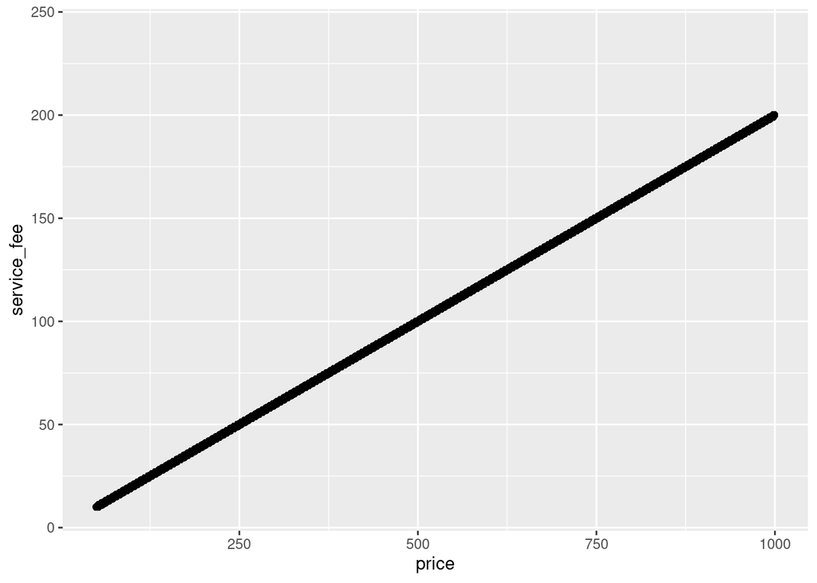

```r
ggplot(data = airbnb_df) +
  geom_point(mapping = aes(x = price, y = service_fee))
```

We recommend keeping the ggplot2 cheatsheet handy while you are going through this project: https://www.rstudio.com/resources/cheatsheets/

### Scatter plot

Now make a scatter plot that explores if `price` is related to one of the other numeric variables in the dataset.

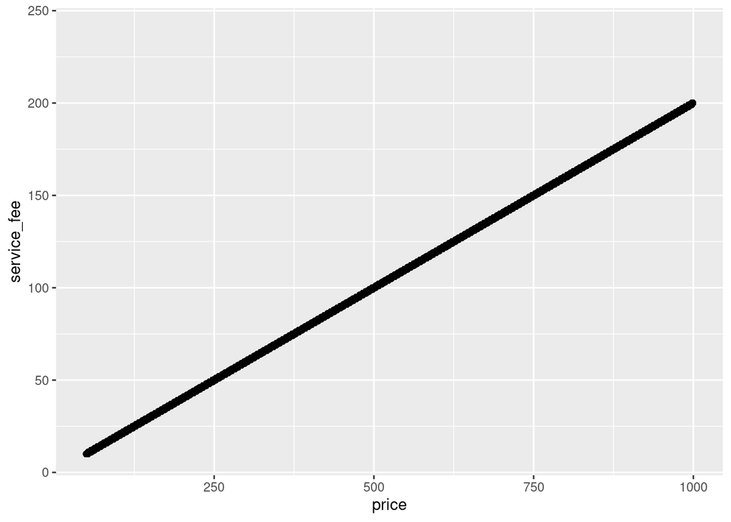

```r
ggplot(data = airbnb_df) +
  geom_point(mapping = aes(x = price, y = service_fee))
```

Make a violin plot for the price distribution of different neighborhood groups.

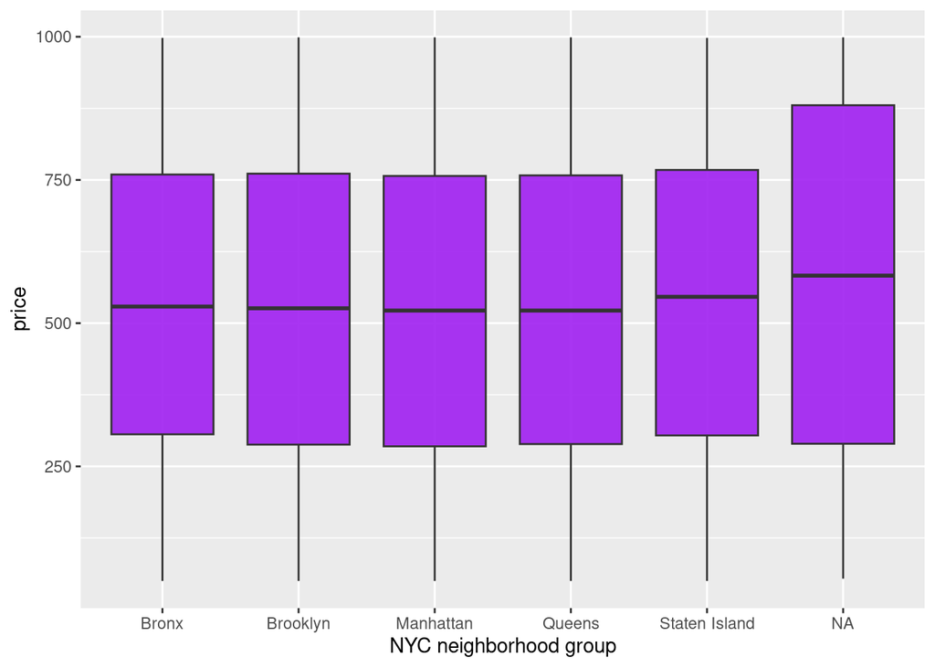

```r
### Your code here
#ggplot(data = airbnb_df) +
 # geom_boxplot(aes(y = price, x = neighbourhood_group), fill = "purple")

ggplot(airbnb_df, aes(x= neighbourhood_group, y = price))+
  geom_boxplot(fill = "purple", alpha = 0.9) +
  xlab("NYC neighborhood group")
```

### Barplot

Now make a plot that explores if there’s a particular `room_type` that has a higher price than others. You may choose to summarize the `price` by the `room_type`. Hint: you may need to `group_by` a variable.

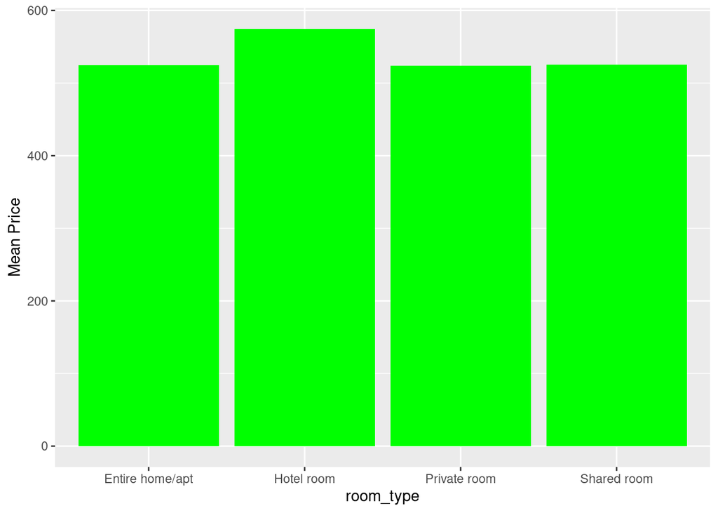

```r
airbnb_df %>%
  group_by(room_type) %>%
  summarize(price = mean(price, na.rm = T))%>%
  ggplot(aes(x = room_type, y = price)) +
  geom_col(fill = "green", stat = "identity")+
  ylab("Mean Price")
```

### Your choice plot!

Make one more plot that is completely your choice about what variables you’d like to see the relationships of.

See http://r-statistics.co/Top50-Ggplot2-Visualizations-MasterList-R-Code.html for inspiration and ideas.

Cancellation Policy and Price

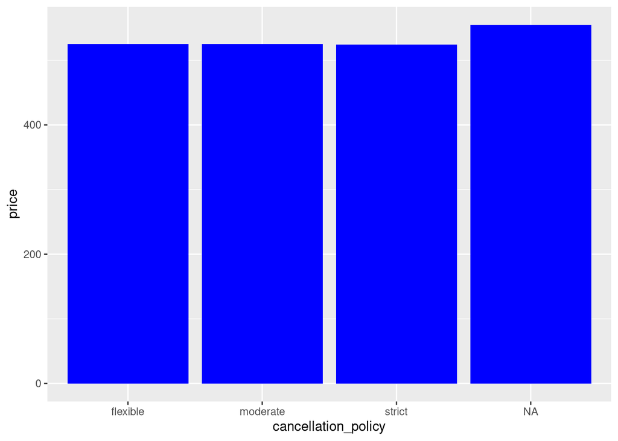

```r
### Your code here
airbnb_df %>%
  group_by(cancellation_policy) %>%
  summarize(price = mean(price, na.rm = TRUE)) %>%
  ggplot(aes(x = cancellation_policy, y = price)) +
  geom_col(fill = "blue", stat = "identity")
```

Ratings vs Cost

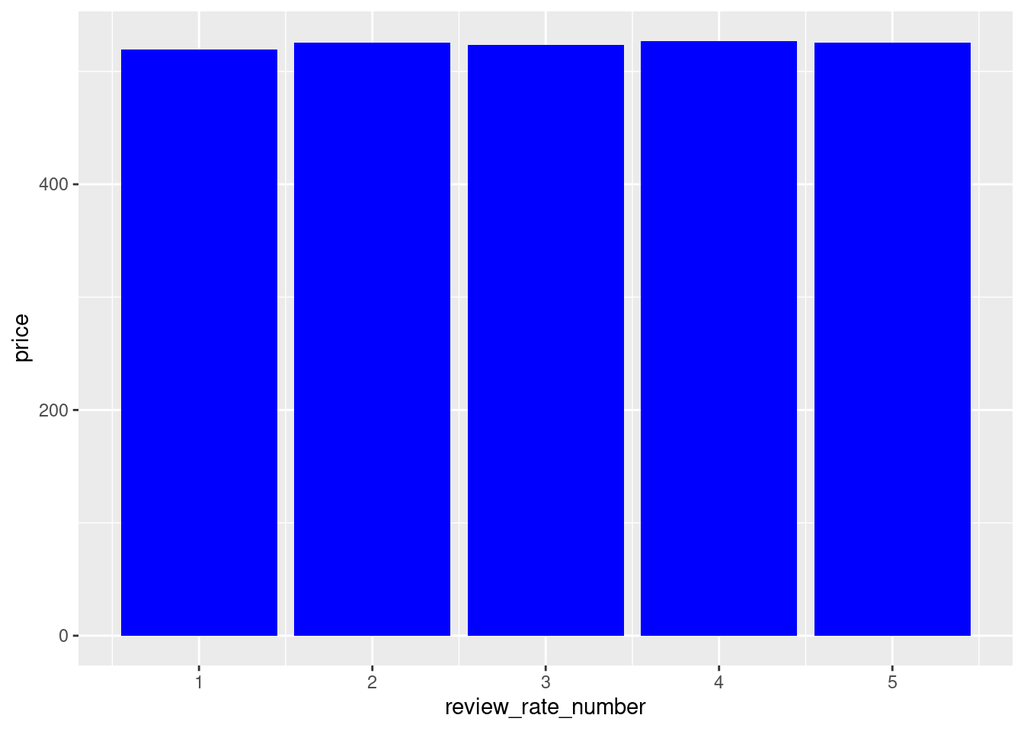

```r
### Your code here
airbnb_df %>%
  group_by(review_rate_number) %>%
  summarize(price = mean(price, na.rm = TRUE)) %>%
  ggplot(aes(x = review_rate_number, y = price)) +
  geom_col(fill = "blue", stat = "identity")
```

Construction Year vs Price

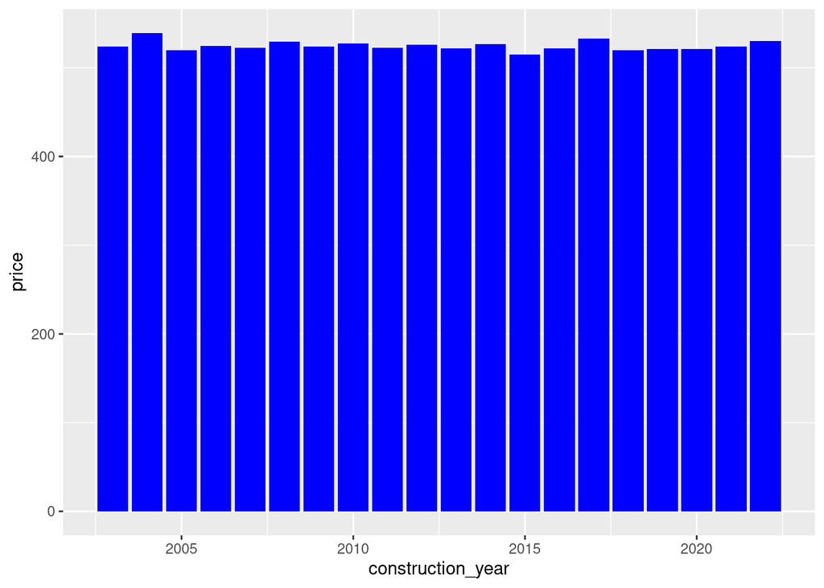

```r
### Your code here
airbnb_df %>%
  group_by(construction_year) %>%
  summarize(price = mean(price, na.rm = TRUE)) %>%
  ggplot(aes(x = construction_year, y = price)) +
  geom_col(fill = "blue", stat = "identity")
```

### Conclusion

Write up your thoughts about this data science project here and answer the following questions:

- What did we find out about our questions?
- How did we explore our questions?
- What did our explorations show us?
- What follow up data science questions arise for you regarding this candy dataset now that we’ve explored it some?

We found that most of the variables in the data frame seem to not have a relationship with the price of the airbnb. The variable that we found related closest to the cost of an AirBnB is “service fee” and the “room type” as the bigger the service fee the higher the cost and if the airbnb has a hotel style room, then the price is said to be more than usual. We found this by creating graphs and plots and comparing these plots with each other to notice trends and differences. Some follow up questions can include; Are there other factors that can affect airbnb prices? Are prices affected by the types of rules? Can the size of the house cause a factor?

## Print out session info

Session info is a good thing to print out at the end of your notebooks so that you (and other folks) referencing your notebooks know what software versions and libraries you used to run the notebook.

[session information not shown]